# FigureYa111markerGene_step1

小丫画图出品

2019-6-30

欢迎关注“小丫画图”公众号，同名知识星球等你加入

小丫微信: epigenomics E-mail: figureya@126.com

作者：徐洲更，欢迎关注他的简书https://www.jianshu.com/u/9ea40b5f607a

小丫编辑校验

## 需求描述

用Seurat找marker基因，用scanpy画出文章里这种热图，中间顺利衔接。

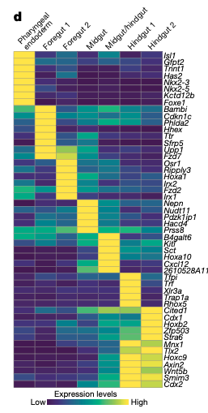

出自https://www.nature.com/articles/s41586-019-0933-9

Fig. 2d, Heat map illustrating the row-normalized mean expression of marker genes for each maturing gut cluster.

## 应用场景

本文档用Seurat进行单细胞上游分析，得到聚类信息和聚类注释信息，使用我写的函数保存结果，然后打开FigureYa111markerGene.ipynb文件，用Scanpy画美图。

这里是前面用Seurat，后面只是用scanpy的画图功能。当然你也可以从头到尾都用Scanpy来做，这个不包含在本文档范围内。

## 环境设置

要求:

- 操作系统: Windows10（内存64G)的运行环境是WSL， MacOS，Linux(Ubuntu/CentOS)，
- 电脑内存: 最低8G， 推荐16G起步，上不封顶
- 掌握shell的基本使用方法

安装Seurat包

```r
install.packages('Seurat')
```

加载包

```r
library(dplyr)
library(Seurat)
Sys.setenv(LANGUAGE = "en") #显示英文报错信息
options(stringsAsFactors = FALSE) #禁止chr转成factor
```

## 输入文件

示例文件保存在当前文件夹下的filtered_gene_bc_matrices/hg19/文件夹里

```r
pbmc.data <- Read10X(data.dir = "filtered_gene_bc_matrices/hg19/")

pbmc <- CreateSeuratObject(counts = pbmc.data,
                           project = "pbmc3k",
                           min.cells = 3, min.features = 200)
```

## Seurat聚类分析

> 下面的步骤是常规的单细胞数据处理流程, 主要是将细胞进行聚类分析, 从而知道每个细胞属于哪一类, 同时根据差异分析结果, 选择标记基因。

数据预处理

```r
pbmc[["percent.mt"]] <- PercentageFeatureSet(pbmc, pattern = "^MT-")
pbmc <- subset(pbmc, subset = nFeature_RNA > 200 &
                 nFeature_RNA < 2500 &
                 percent.mt < 5)
pbmc <- NormalizeData(pbmc,
                      normalization.method = "LogNormalize",
                      scale.factor = 10000)
pbmc <- FindVariableFeatures(pbmc,
                             selection.method = "vst",
                             nfeatures = 2000)
all.genes <- rownames(pbmc)
pbmc <- ScaleData(pbmc, features = all.genes)
pbmc <- RunPCA(pbmc, features = VariableFeatures(object = pbmc))
```

```
## PC_ 1
## Positive:  CST3, TYROBP, LST1, AIF1, FTL, FTH1, LYZ, FCN1, S100A9, TYMP
##     FCER1G, CFD, LGALS1, S100A8, CTSS, LGALS2, SERPINA1, IFITM3, SPI1, CFP
##     PSAP, IFI30, SAT1, COTL1, S100A11, NPC2, GRN, LGALS3, GSTP1, PYCARD
## Negative:  MALAT1, LTB, IL32, IL7R, CD2, B2M, ACAP1, CD27, STK17A, CTSW
##     CD247, GIMAP5, AQP3, CCL5, SELL, TRAF3IP3, GZMA, MAL, CST7, ITM2A
##     MYC, GIMAP7, HOPX, BEX2, LDLRAP1, GZMK, ETS1, ZAP70, TNFAIP8, RIC3
## PC_ 2
## Positive:  CD79A, MS4A1, TCL1A, HLA-DQA1, HLA-DQB1, HLA-DRA, LINC00926, CD79B, HLA-DRB1, CD74
##     HLA-DMA, HLA-DPB1, HLA-DQA2, CD37, HLA-DRB5, HLA-DMB, HLA-DPA1, FCRLA, HVCN1, LTB
##     BLNK, P2RX5, IGLL5, IRF8, SWAP70, ARHGAP24, FCGR2B, SMIM14, PPP1R14A, C16orf74
## Negative:  NKG7, PRF1, CST7, GZMB, GZMA, FGFBP2, CTSW, GNLY, B2M, SPON2
##     CCL4, GZMH, FCGR3A, CCL5, CD247, XCL2, CLIC3, AKR1C3, SRGN, HOPX
##     TTC38, APMAP, CTSC, S100A4, IGFBP7, ANXA1, ID2, IL32, XCL1, RHOC
## PC_ 3
## Positive:  HLA-DQA1, CD79A, CD79B, HLA-DQB1, HLA-DPB1, HLA-DPA1, CD74, MS4A1, HLA-DRB1, HLA-DRA
##     HLA-DRB5, HLA-DQA2, TCL1A, LINC00926, HLA-DMB, HLA-DMA, CD37, HVCN1, FCRLA, IRF8
##     PLAC8, BLNK, MALAT1, SMIM14, PLD4, LAT2, IGLL5, P2RX5, SWAP70, FCGR2B
## Negative:  PPBP, PF4, SDPR, SPARC, GNG11, NRGN, GP9, RGS18, TUBB1, CLU
##     HIST1H2AC, AP001189.4, ITGA2B, CD9, TMEM40, PTCRA, CA2, ACRBP, MMD, TREML1
##     NGFRAP1, F13A1, SEPT5, RUFY1, TSC22D1, MPP1, CMTM5, RP11-367G6.3, MYL9, GP1BA
## PC_ 4
## Positive:  HLA-DQA1, CD79B, CD79A, MS4A1, HLA-DQB1, CD74, HLA-DPB1, HIST1H2AC, PF4, TCL1A
##     SDPR, HLA-DPA1, HLA-DRB1, HLA-DQA2, HLA-DRA, PPBP, LINC00926, GNG11, HLA-DRB5, SPARC
##     GP9, AP001189.4, CA2, PTCRA, CD9, NRGN, RGS18, GZMB, CLU, TUBB1
## Negative:  VIM, IL7R, S100A6, IL32, S100A8, S100A4, GIMAP7, S100A10, S100A9, MAL
##     AQP3, CD2, CD14, FYB, LGALS2, GIMAP4, ANXA1, CD27, FCN1, RBP7
##     LYZ, S100A11, GIMAP5, MS4A6A, S100A12, FOLR3, TRABD2A, AIF1, IL8, IFI6
## PC_ 5
## Positive:  GZMB, NKG7, S100A8, FGFBP2, GNLY, CCL4, CST7, PRF1, GZMA, SPON2
##     GZMH, S100A9, LGALS2, CCL3, CTSW, XCL2, CD14, CLIC3, S100A12, CCL5
##     RBP7, MS4A6A, GSTP1, FOLR3, IGFBP7, TYROBP, TTC38, AKR1C3, XCL1, HOPX
## Negative:  LTB, IL7R, CKB, VIM, MS4A7, AQP3, CYTIP, RP11-290F20.3, SIGLEC10, HMOX1
##     PTGES3, LILRB2, MAL, CD27, HN1, CD2, GDI2, ANXA5, CORO1B, TUBA1B
##     FAM110A, ATP1A1, TRADD, PPA1, CCDC109B, ABRACL, CTD-2006K23.1, WARS, VMO1, FYB
```

```r
pbmc <- FindNeighbors(pbmc, dims = 1:10)
```

聚类分析

```r
pbmc <- FindClusters(pbmc, resolution = 0.5)
```

```
## Modularity Optimizer version 1.3.0 by Ludo Waltman and Nees Jan van Eck
##
## Number of nodes: 2638
## Number of edges: 96033
##
## Running Louvain algorithm...
## Maximum modularity in 10 random starts: 0.8720
## Number of communities: 9
## Elapsed time: 0 seconds
```

定义cluster

```r
new.cluster.ids <- c("Naive CD4 T",
                     "Memory CD4 T",
                     "CD14+ Mono",
                     "B",
                     "CD8 T",
                     "FCGR3A+ Mono",
                     "NK",
                     "DC",
                     "Platelet")
names(new.cluster.ids) <- levels(pbmc)
pbmc <- RenameIdents(pbmc, new.cluster.ids)
```

这里可以接UMAP看聚类结果，关于UMAP的安装和详细用法，可参考FigureYa93UMAP。

```r
pbmc <- RunUMAP(pbmc, dims = 1:10)
DimPlot(pbmc, reduction = "umap", label = T)
```

[output not shown]

## 开始画图

用Seurat展示标记基因

### 定义基因

```r
marker_gene <- c("IL7R", "CCR7",
                    "S100A4",
                    "CD14", "LYZ",
                 "MS4A1",
                 "CD8A",
                    "FCGR3A", "MS4A7",
                 "GNLY", "NKG7",
                    "FCER1A", "CST3",
                 "PPBP")
```

### 热图

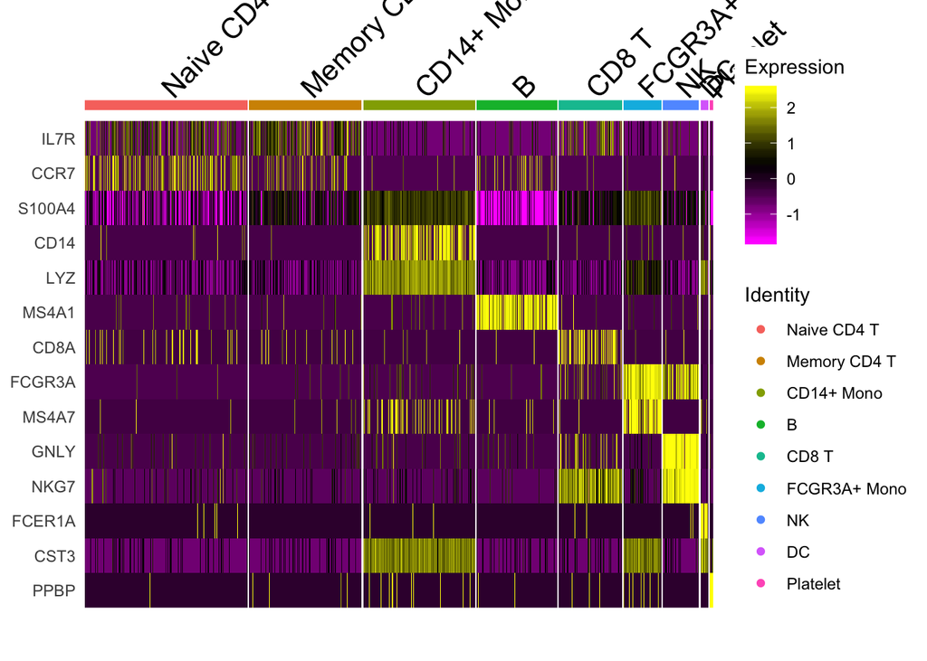

```r
DoHeatmap(pbmc, features = marker_gene)
```

### 小提琴图

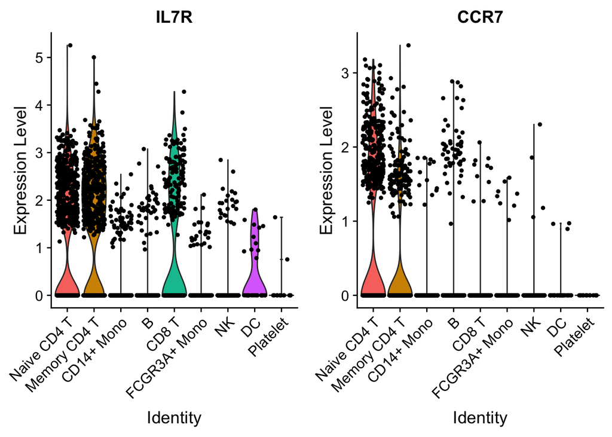

```r
VlnPlot(pbmc,
        features = marker_gene[1:2])
```

> 除了这两种，还能不能有更加好看的展现方式？

Scanpy提供了许多种好看的展示方式，见https://scanpy-tutorials.readthedocs.io/en/latest/visualizing-marker-genes.html

那么如何将Seruat的结果和Scanpy进行结合呢？我们首先需要把结果输出到文件，然后用Scanpy画美图。

## 输出Seurat结果

Seurat的表达量数据存放在`@assays$RNA`下,

- counts: TPM或者UMI信息, 最初的输入信息
- data: 标准化结果
- scale.data: scale后的数据

Seurat的细胞的各种元信息在`@meta.data`下

Seurat定义后细胞类型的数据在`@active.ident`下,

我写了一个函数`seurat2scanpy`, 将上面信息保存在同一个文件夹下

```r
source("seurat2scanpy.R")
seurat2scanpy(x = pbmc)
```

后续的操作在Jupyter notebook进行。你需要：

- 下载并安装Anaconda发行版，https://www.anaconda.com/distribution/#download-section
- 用Jupyter notebook打开FigureYa111markerGene_step2_linuxMAC.ipynb或FigureYa111markerGene_step2_win10.ipynb文档继续画图。
- ipynb文档的用法参考这篇：https://mp.weixin.qq.com/s/G-CQhNEJBmMRuDe2kxND_w

## 参考资料

- https://scanpy.readthedocs.io/